# 在线课程-网络数据结构Task5

杜兴兴

2021/3/18

## 准备工作

```r
# 清除工作环境
rm(list = ls())
library(igraph)  # 加载必要包
```

## 绘制度分布的直方图，并且做简要解读

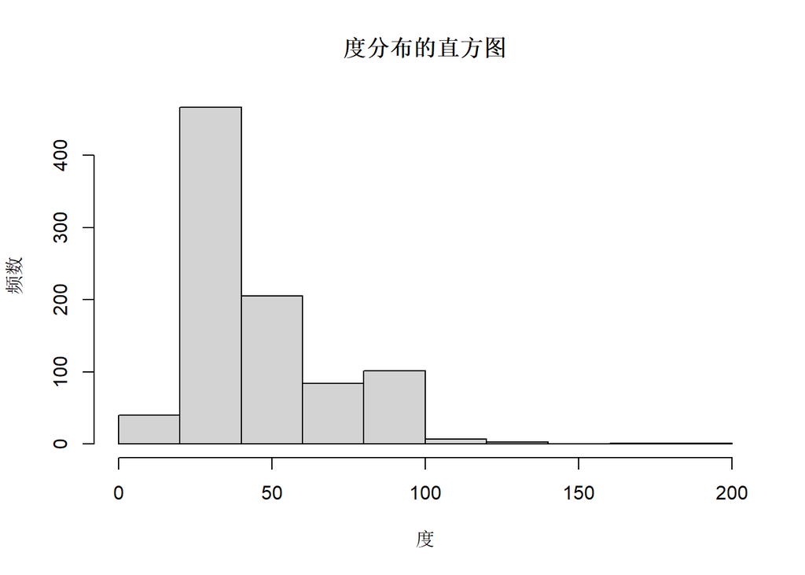

```r
edge = read.csv("../A2_data/edge.csv",header = T)

g = graph_from_data_frame(edge,directed = F)  # 构建网络
dg = degree(g,mode = "all")  # 计算节点度
hist(dg,main = "度分布的直方图",xlab = "度",ylab = "频数")  # 绘制度分布的直方图
```

通过观察上面直方图可以发现，节点的分布基本呈现右偏，大部分节点的度都在0-100范围内，节点度大于100的只有极少数。

## 计算度中心性指标

```r
sort_value <- function(x){  # 自定义排序函数
    index = order(x,decreasing = T)[1:10]
    return(list(index = index,
                value = x[index]))
}
sort_value(degree(g,mode = "all",normalized = T))
```

```
## $index
##  [1] 167 171 137 797 168 596 501 127 154 611
##
## $value
##  porcu,emilio   mateu,jorge       kent,jt   critchley,f stehlik,milan
##     0.2039691     0.1984564     0.1455347     0.1356119     0.1345094
##   longford,nt      nason,gp        yao,qw  richardson,s        cox,dr
##     0.1312018     0.1278942     0.1223815     0.1212789     0.1190739
```

```r
sort_value(closeness(g,mode = "all",normalized = T))
```

```
## $index
##  [1] 596 611 154 524 797 127 117   4 137 502
##
## $value
##  longford,nt       cox,dr richardson,s  atkinson,ac  critchley,f       yao,qw
##  0.004921271  0.004920123  0.004919989  0.004919482  0.004919055  0.004918095
## johnstone,im    yu,keming      kent,jt   glasbey,ca
##  0.004917935  0.004917642  0.004917215  0.004917188
```

- 根据度中心性度量指标，标号为167、171、137、797、168、596、501、127、 154和611的节点比较重要，说明这些结点所代表的作者与所有其他作者的相联系的程度较高，在网络中的参会度高。
- 根据接近中兴性度量指标，标号为596、611、154、524、797、127、117、4、137、502的节点比较重要，说明这些节点所代表的作者与其它作业的“相近”程度最高。

## 作者简要介绍：

stehlik,milan 的研究着重于多文化选择的发展，尤其是癌症治疗，金融以及生态系统的发展。主要从事神经计算与应用研究。包括：医学统计、生态统计学、代数统计学、优化设计、极值理论、波动率模型、随机近似等方面。

- [1] Milan Stehlík & Rastislav Potocký & Helmut Waldl & Zdeněk Fabián, 2010. “On the favorable estimation for fitting heavy tailed data,” Computational Statistics, Springer, vol. 25(3), pages 485-503, September.
- [2] Milan Stehlík & Juan Rodríguez-Díaz & Werner Müller & Jesús López-Fidalgo, 2008. “Optimal allocation of bioassays in the case of parametrized covariance functions: an application to Lung’s retention of radioactive particles,” TEST: An Official Journal of the Spanish Society of Statistics and Operations Research, Springer;Sociedad de Estadística e Investigación Operativa, vol. 17(1), pages 56-68, May.
- [3] Kiselák, Jozef & Stehlík, Milan, 2008. “Equidistant and D-optimal designs for parameters of Ornstein-Uhlenbeck process,” Statistics & Probability Letters, Elsevier, vol. 78(12), pages 1388-1396, September.
- [4] Stehlík, Milan, 2006. “Exact likelihood ratio scale and homogeneity testing of some loss processes,” Statistics & Probability Letters, Elsevier, vol. 76(1), pages 19-26, January.